# Baby Names Analysis

Shrikant Anand

# 1 - Etapa inicial

> 1. **Cargo librerías**

```r
suppressPackageStartupMessages( {
  library(babynames)
  library(ukbabynames)
  library(dplyr)
  library(data.table)
  library(tidyr)
  library(tidytable)
  library(ggplot2)
  library(rmarkdown)
   library(skimr)
  library(gridExtra)
  library(wordcloud2)
})
```

> 2. **Cargo datos**

```r
data1 = as.data.table(babynames)
data2 = as.data.table(ukbabynames)
```

```r
paged_table(head(data1))
```

| year | sex | name | n | prop |
| --- | --- | --- | --- | --- |
| 1880 | F | Mary | 7065 | 0.07238359 |
| 1880 | F | Anna | 2604 | 0.02667896 |
| 1880 | F | Emma | 2003 | 0.02052149 |
| 1880 | F | Elizabeth | 1939 | 0.01986579 |
| 1880 | F | Minnie | 1746 | 0.01788843 |
| 1880 | F | Margaret | 1578 | 0.01616720 |

```r
paged_table(head(data2))
```

| year | sex | name | n | rank | nation |
| --- | --- | --- | --- | --- | --- |
| 1996 | F | SOPHIE | 7087 | 1 | England & Wales |
| 1996 | F | CHLOE | 6824 | 2 | England & Wales |
| 1996 | F | JESSICA | 6711 | 3 | England & Wales |
| 1996 | F | EMILY | 6415 | 4 | England & Wales |
| 1996 | F | LAUREN | 6299 | 5 | England & Wales |
| 1996 | F | HANNAH | 5916 | 6 | England & Wales |

**Descripción de las bases de datos**

1. **Babynames**

Datos completos de nombres de bebés entre 1880-2017 para los Estados Unidos. Un conjunto de datos con cinco variables:

**year** - año.

**sex** - sexo, M para hombre y F para mujer.

**name** - nombre.

**n** - cantidad de nombres por año y sexo.

**prop** - (n dividido por el número total de solicitantes en ese año, lo que significa que las proporciones son de personas de ese sexo con ese nombre nacidas en ese año).

2. **Ukbabynames**

Datos completos de nombres de bebés entre 1974-2020 para el Reino Unido de todas las naciones. Contiene datos de Inglaterra y Gales (ewbabynames), Escocia (scotbabynames) e Irlanda del Norte (nibabynames).

Un conjunto de datos con 565.817 observaciones sobre 6 variables.

**year** - año.

**sex** - sexo, M para hombre y F para mujer.

**name** - nombre.

**n** - cantidad de nombres por año y sexo.

**rank** - ranking del nombre en el año y sexo.

**nation** - país de origen de los datos.

Estructura inicial y análisis de los conjuntos de datos:

```r
skim(data1)
```

Data summary

| Name | data1 |
| --- | --- |
| Number of rows | 1924665 |
| Number of columns | 5 |
| Key | NULL |
| _______________________ |  |
| Column type frequency: |  |
| character | 2 |
| numeric | 3 |
| ________________________ |  |
| Group variables | None |

**Variable type: character**

| skim_variable | n_missing | complete_rate | min | max | empty | n_unique | whitespace |
| --- | --- | --- | --- | --- | --- | --- | --- |
| sex | 0 | 1 | 1 | 1 | 0 | 2 | 0 |
| name | 0 | 1 | 2 | 15 | 0 | 97310 | 0 |

**Variable type: numeric**

| skim_variable | n_missing | complete_rate | mean | sd | p0 | p25 | p50 | p75 | p100 | hist |
| --- | --- | --- | --- | --- | --- | --- | --- | --- | --- | --- |
| year | 0 | 1 | 1974.85 | 34.03 | 1880 | 1951 | 1985 | 2003 | 2017.00 | ▁▂▃▅▇ |
| n | 0 | 1 | 180.87 | 1533.34 | 5 | 7 | 12 | 32 | 99686.00 | ▇▁▁▁▁ |
| prop | 0 | 1 | 0.00 | 0.00 | 0 | 0 | 0 | 0 | 0.08 | ▇▁▁▁▁ |

```r
str(data1)
```

```
## Classes 'data.table' and 'data.frame':   1924665 obs. of  5 variables:
##  $ year: num  1880 1880 1880 1880 1880 1880 1880 1880 1880 1880 ...
##  $ sex : chr  "F" "F" "F" "F" ...
##  $ name: chr  "Mary" "Anna" "Emma" "Elizabeth" ...
##  $ n   : int  7065 2604 2003 1939 1746 1578 1472 1414 1320 1288 ...
##  $ prop: num  0.0724 0.0267 0.0205 0.0199 0.0179 ...
##  - attr(*, ".internal.selfref")=<externalptr>
```

```r
anyDuplicated(data1)
```

```
## [1] 0
```

```r
skim(data2)
```

Data summary

| Name | data2 |
| --- | --- |
| Number of rows | 565817 |
| Number of columns | 6 |
| Key | NULL |
| _______________________ |  |
| Column type frequency: |  |
| character | 3 |
| numeric | 3 |
| ________________________ |  |
| Group variables | None |

**Variable type: character**

| skim_variable | n_missing | complete_rate | min | max | empty | n_unique | whitespace |
| --- | --- | --- | --- | --- | --- | --- | --- |
| sex | 0 | 1 | 1 | 1 | 0 | 2 | 0 |
| name | 0 | 1 | 1 | 27 | 0 | 102299 | 0 |
| nation | 0 | 1 | 8 | 16 | 0 | 3 | 0 |

**Variable type: numeric**

| skim_variable | n_missing | complete_rate | mean | sd | p0 | p25 | p50 | p75 | p100 | hist |
| --- | --- | --- | --- | --- | --- | --- | --- | --- | --- | --- |
| year | 0 | 1 | 2005.63 | 10.92 | 1974 | 2000 | 2008 | 2014 | 2020 | ▁▁▃▆▇ |
| n | 0 | 1 | 33.01 | 221.68 | 1 | 1 | 4 | 10 | 10779 | ▇▁▁▁▁ |
| rank | 0 | 1 | 1845.33 | 1552.15 | 1 | 664 | 1258 | 2863 | 5876 | ▇▅▂▂▁ |

```r
str(data2)
```

```
## Classes 'data.table' and 'data.frame':   565817 obs. of  6 variables:
##  $ year  : num  1996 1996 1996 1996 1996 ...
##  $ sex   : chr  "F" "F" "F" "F" ...
##  $ name  : chr  "SOPHIE" "CHLOE" "JESSICA" "EMILY" ...
##  $ n     : num  7087 6824 6711 6415 6299 ...
##  $ rank  : num  1 2 3 4 5 6 7 8 9 10 ...
##  $ nation: chr  "England & Wales" "England & Wales" "England & Wales" "England & Wales" ...
##  - attr(*, ".internal.selfref")=<externalptr>
```

```r
anyDuplicated(data2)
```

```
## [1] 0
```

Arriba vemos la estructura básica de los conjuntos de datos y comprobamos si hay valores duplicados y NAs.

```r
data2 %>% filter(year>=1992, year<=1997) %>% group_by(year,sex,nation) %>% summarise(total = sum(n))
```

```
## # A tidytable: 18 × 4
## # Groups:      year, sex
##     year sex   nation            total
##    <dbl> <chr> <chr>             <dbl>
##  1  1992 F     Scotland          32177
##  2  1992 M     Scotland          33610
##  3  1993 F     Scotland          30961
##  4  1993 M     Scotland          32373
##  5  1994 F     Scotland          30256
##  6  1994 M     Scotland          31397
##  7  1995 F     Scotland          29399
##  8  1995 M     Scotland          30650
##  9  1996 F     England & Wales  295998
## 10  1996 F     Scotland          28771
## 11  1996 M     England & Wales  318517
## 12  1996 M     Scotland          30523
## 13  1997 F     England & Wales  293182
## 14  1997 F     Northern Ireland  10592
## 15  1997 F     Scotland          28924
## 16  1997 M     England & Wales  314454
## 17  1997 M     Northern Ireland  11705
## 18  1997 M     Scotland          30515
```

Podemos observar que en el conjunto de datos ukbabynames, hasta el año 1995 sólo hay entradas de Escocia y sólo después de 1996 se añaden datos de Inglaterra y Gales e Irlanda del Norte. Teniendo esto en cuenta, es posible que veamos algunos picos en los gráficos de los años 1995 y 1996, en los que se utilizará el n total.

Voy a hacer algunos cambios en los conjuntos de datos para tener información similar en ambos conjuntos.

Como quiero que mi análisis sea sencillo y fácil de entender, sólo incluyo dos países (US y UK) y ninguno más.

```r
data1$country = "US"
data2$country = "UK"
data2$nation = NULL
```

En el conjunto de datos babynames, creamos la variable rank. Además, creamos la variable prop en UKbabynames.

```r
data1 <- data1 %>%
  group_by(year, sex) %>%
  mutate(rank = dense_rank(desc(n)))

data2 <- data2 %>%
  group_by(year) %>%
  mutate(prop = n / sum(n)) %>%
  ungroup()
```

Observamos head de dos tablas.

```r
paged_table(head(data1))
```

| year | sex | name | n | prop | country | rank |
| --- | --- | --- | --- | --- | --- | --- |
| 1880 | F | Mary | 7065 | 0.07238359 | US | 1 |
| 1880 | F | Anna | 2604 | 0.02667896 | US | 2 |
| 1880 | F | Emma | 2003 | 0.02052149 | US | 3 |
| 1880 | F | Elizabeth | 1939 | 0.01986579 | US | 4 |
| 1880 | F | Minnie | 1746 | 0.01788843 | US | 5 |
| 1880 | F | Margaret | 1578 | 0.01616720 | US | 6 |

```r
paged_table(head(data2))
```

| year | sex | name | n | rank | country | prop |
| --- | --- | --- | --- | --- | --- | --- |
| 1996 | F | SOPHIE | 7087 | 1 | UK | 0.010517817 |
| 1996 | F | CHLOE | 6824 | 2 | UK | 0.010127499 |
| 1996 | F | JESSICA | 6711 | 3 | UK | 0.009959796 |
| 1996 | F | EMILY | 6415 | 4 | UK | 0.009520502 |
| 1996 | F | LAUREN | 6299 | 5 | UK | 0.009348346 |
| 1996 | F | HANNAH | 5916 | 6 | UK | 0.008779936 |

Ahora los juntamos. Aquí también volvemos a crear las variables prop y rank.

```r
data3 <- rbind(data1, data2)

data3 <- data3 %>%
  group_by(year) %>%
  mutate(prop = n / sum(n)) %>%
  ungroup()

data3 <- data3 %>%
  group_by(year, sex) %>%
  mutate(rank = dense_rank(desc(n)))
paged_table(head(data3))
```

| year | sex | name | n | prop | country | rank |
| --- | --- | --- | --- | --- | --- | --- |
| 1880 | F | Mary | 7065 | 0.035064819 | US | 1 |
| 1880 | F | Anna | 2604 | 0.012924103 | US | 2 |
| 1880 | F | Emma | 2003 | 0.009941236 | US | 3 |
| 1880 | F | Elizabeth | 1939 | 0.009623593 | US | 4 |
| 1880 | F | Minnie | 1746 | 0.008665701 | US | 5 |
| 1880 | F | Margaret | 1578 | 0.007831887 | US | 6 |

# 2 - Análisis - US

Empezaremos por ver los nombres más populares en US para el primer y el último año del conjunto de datos.

> 1. **Año 1880**

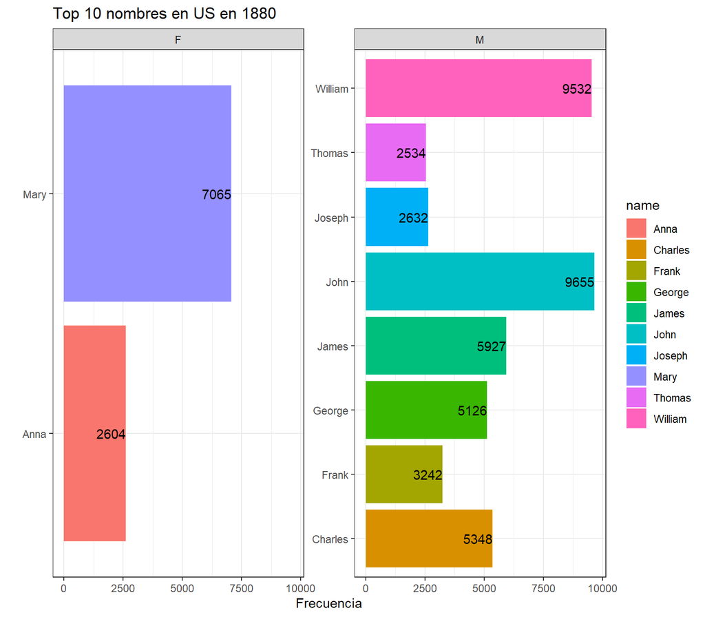

```r
data <- data1 %>%
  filter(year == 1880) %>%
  select(name, n, sex) %>%
  group_by(name,sex) %>%
  summarise(total = sum(n)) %>%
  arrange(desc(total)) %>%
  head(10)

ggplot(data, aes(x = name, y = total, fill = name)) +
  geom_col() +
  geom_text(aes(label = total), vjust = 0.5,hjust = 1) +
  labs(x = "", y = "Frecuencia", title = "Top 10 nombres en US en 1880") +
  theme_bw() +
    coord_flip()+
    facet_wrap(~sex, scales = "free_y")
```

Podemos ver que los nombres Mary y Anna eran los más populares entre las chicas, mientras que William y John eran famosos entre los chicos.

Ahora cogemos los 2 nombres más populares de chicos y chicas en 1880 y vemos sus tendencias a lo largo de los años.

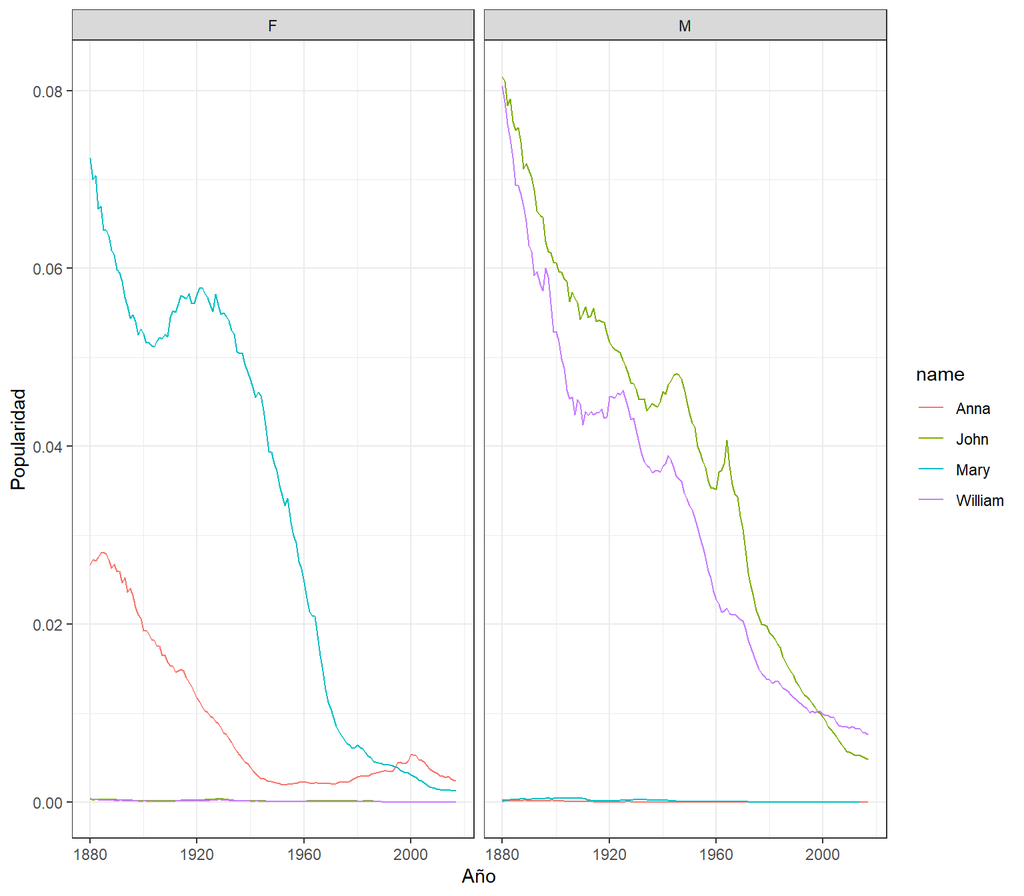

```r
data1 %>%
  select(year, name, prop, sex) %>%
  filter(name %in% c('Mary', 'Anna', 'William', 'John')) %>%
  ggplot(aes(year, prop, color = name)) +
    xlab("Año") +
  ylab("Popularidad") +
  geom_line() +
  facet_wrap(~ sex, ncol = 2)+
  theme_bw()
```

> 2. **Año 2017**

Ahora vemos los nombres populares en el año 2017 y sus tendencias.

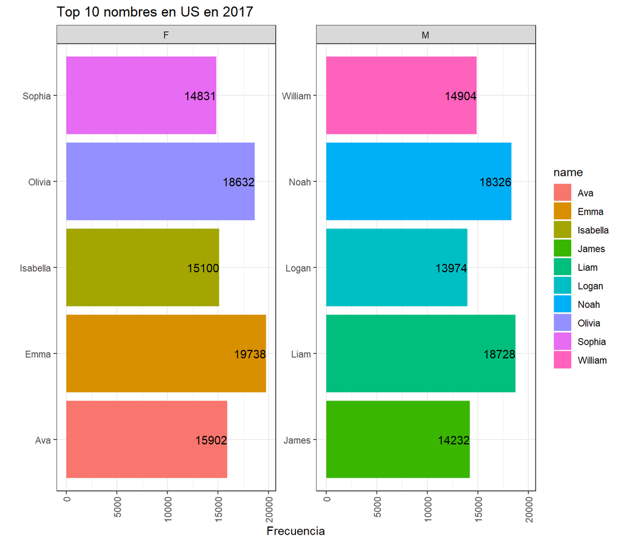

```r
data <- data1 %>%
  filter(year == 2017) %>%
  select(name, n, sex) %>%
  group_by(name,sex) %>%
  summarise(total = sum(n)) %>%
  arrange(desc(total)) %>%
  head(10)

ggplot(data, aes(x = name, y = total, fill = name)) +
  geom_col() +
  geom_text(aes(label = total), vjust = 0.5,hjust = 1)+
  labs(x = "", y = "Frecuencia", title = "Top 10 nombres en US en 2017") +
  theme_bw() +
  theme(axis.text.x = element_text(angle = 90, vjust = 0.5, hjust=1))+
  coord_flip()+facet_grid(.~sex)+
  facet_wrap(~sex, scales = "free_y")
```

En el año 2017, Emma y Olivia fueron los nombres más elegidos para las chicas. Para los chicos, lo fueron Liam y Noah.

Veamos sus tendencias

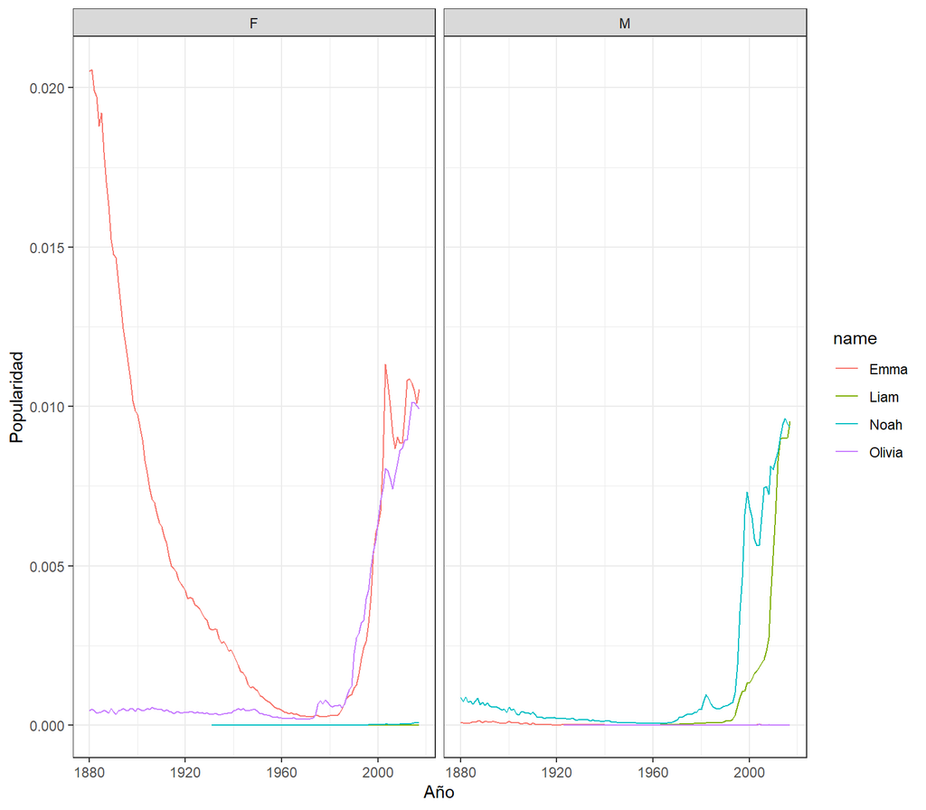

```r
data1 %>%
  select(year, name, prop, sex) %>%
  filter(name %in% c('Emma', 'Olivia', 'Liam', 'Noah')) %>%
  ggplot(aes(year, prop, color = name)) +
    xlab("Año") +
  ylab("Popularidad") +
  geom_line(size = 0.5) +
  facet_wrap(~ sex, ncol = 2)+
  theme_bw()
```

Emma fue una elección preferida a finales de los 1800, luego fue decayendo y empezó a ganar popularidad de nuevo alrededor de 1980. Otros nombres no eran tan populares antes, pero también lo fueron después de 1980.

> 3. **Nombres únicos**

Aquí vemos la cantidad de nombres únicos elegidos por la gente cada año.

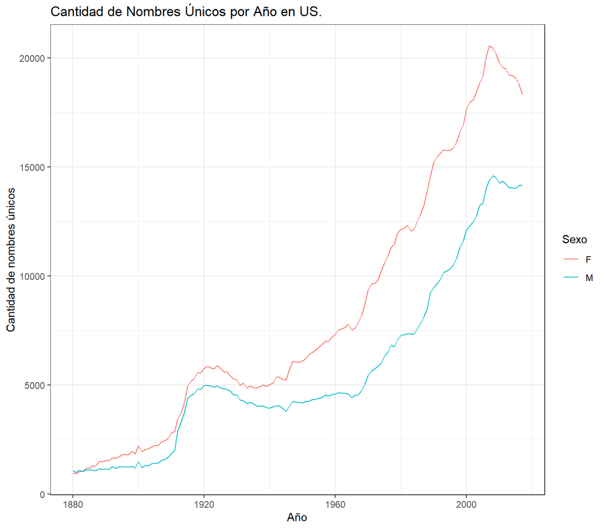

```r
unique_names <- data1 %>%
  group_by(year, sex) %>%
  summarize(unique_count = n_distinct(name)) %>%
  ungroup()

ggplot(unique_names, aes(x = year, y = unique_count, color = sex)) +
  geom_line() +
  labs(title = "Cantidad de Nombres Únicos por Año en US.",
       x = "Año", y = "Cantidad de nombres únicos", color = "Sexo") +
    theme_bw()
```

Vemos que los nombres únicos mantuvieron una tendencia positiva, lo que indica que la gente ha sido creativa a lo largo de los años.

# 3 - Análisis - UK

Aquí haremos un análisis similar pero ahora para “UK”.

> 1. **Año 1974**

Empezaremos por ver los nombres más populares en UK para el primer y el último año del conjunto de datos.

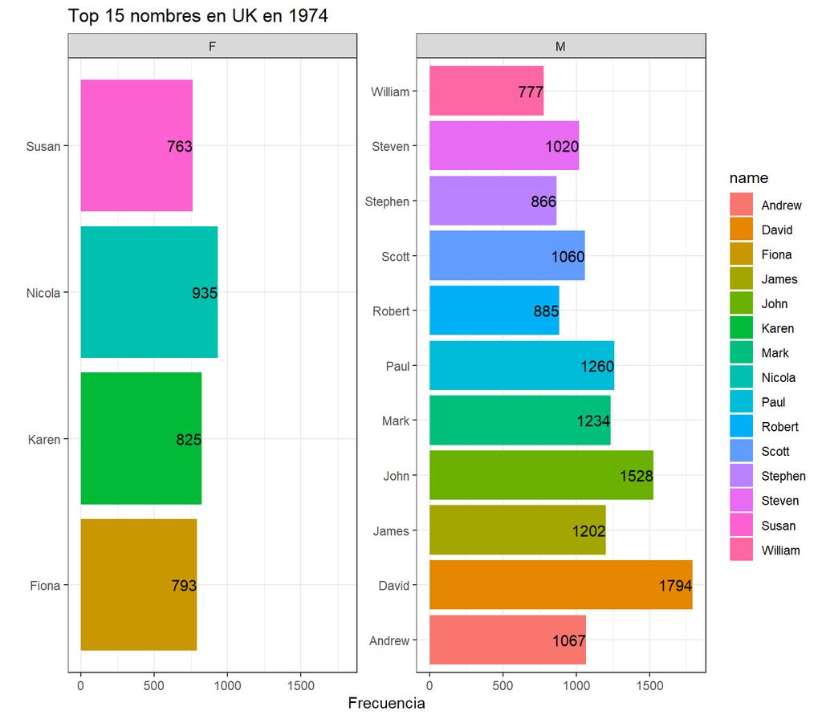

```r
data <- data2 %>%
  filter(year == 1974) %>%
  select(name, n, sex) %>%
  group_by(name,sex) %>%
  summarise(total = sum(n)) %>%
  arrange(desc(total)) %>%
  head(15)

ggplot(data, aes(x = name, y = total, fill = name)) +
  geom_col() +
  geom_text(aes(label = total), vjust = 0.5,hjust = 1)+
  labs(x = "", y = "Frecuencia", title = "Top 15 nombres en UK en 1974") +
  theme_bw() +
    coord_flip()+
    facet_wrap(~sex, scales = "free_y")
```

Podemos ver que los nombres Nicola,Karen,Fiona,Susan fueron los más populares entre las chicas, mientras que David y John fueron famosos entre los chicos.

Ahora cogemos los 2 nombres más populares de chicos y chicas de 1974 y vemos sus tendencias a lo largo de los años.

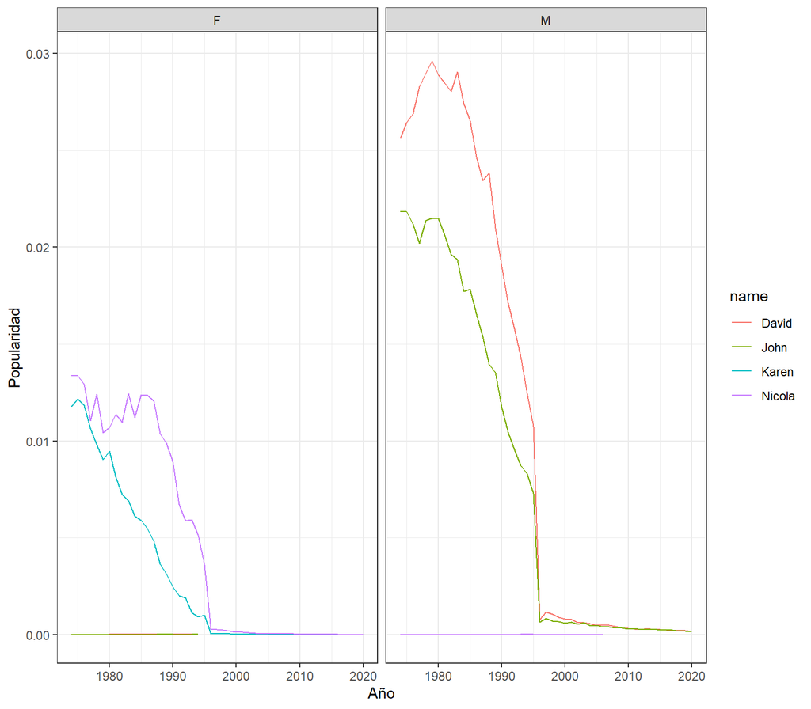

```r
data2 %>%
  select(year, name, prop, sex) %>%
  filter(name %in% c('Nicola', 'Karen', 'David', 'John')) %>%  group_by(name,year,sex) %>% summarise(prop = sum(prop)) %>%
  ggplot(aes(year, prop, color = name)) +
  geom_line(size = 0.5) +
    xlab("Año") +
  ylab("Popularidad") +
  facet_wrap(~ sex, ncol = 2)+
  theme_bw()
```

Como podemos ver, tras ser populares, todos los nombres se volvieron muy impopulares a partir de 1996. En ese año, se observa un descenso pronunciado, debido a la incorporación de nuevos datos a la base de datos.

> 2. **Año 2020**

Ahora vemos los nombres populares de 2020.

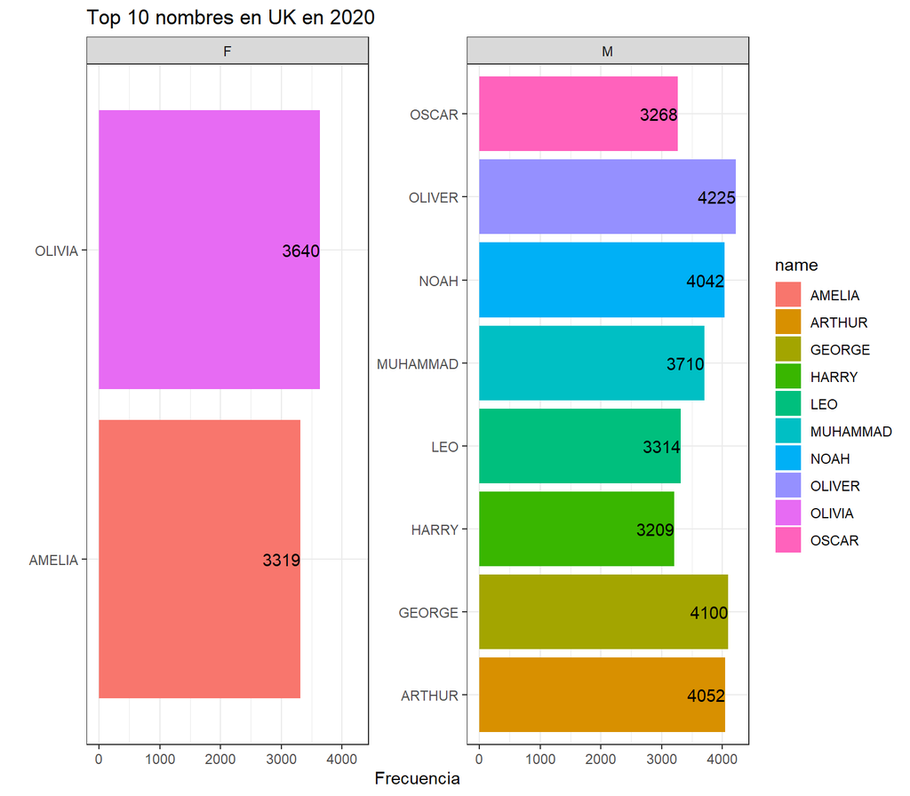

```r
data <- data2 %>%
  filter(year == 2020) %>%
  select(name, n, sex) %>%
  group_by(name,sex) %>%
  summarise(total = sum(n)) %>%
  arrange(desc(total)) %>%
  head(10)

ggplot(data, aes(x = name, y = total, fill = name)) +
  geom_col() +
  labs(x = "", y = "Frecuencia", title = "Top 10 nombres en UK en 2020") +
  theme_bw() +
  geom_text(aes(label = total), vjust = 0.5,hjust = 1)+
    coord_flip()+facet_grid(.~sex)+
  facet_wrap(~sex, scales = "free_y")
```

En el año 2020, Olivia y Amelia fueron los nombres más elegidos entre las chicas. Entre los chicos, lo fueron Oliver, George,Arthur,Noah. Ahora vemos sus tendencias.

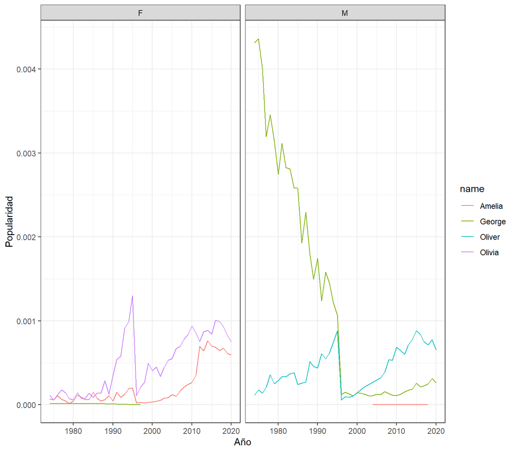

```r
data2 %>%
  select(year, name, prop,sex) %>%
  filter(name %in% c('Olivia', 'Amelia', 'Oliver', 'George')) %>% group_by(name,year,sex) %>% summarise(prop = sum(prop)) %>%
  ggplot(aes(year, prop, color = name)) +
  geom_line(size = 0.5) +
    xlab("Año") +
  ylab("Popularidad") +
  facet_wrap(~ sex, ncol = 2)+
  theme_bw()
```

George era un nombre muy popular a finales de los años 1900. Oliver y Olivia eran populares a finales del año 1990, pero también lo siguieron siendo en los años siguientes. Amelia ganó popularidad después del año 2000.

> 3. **Nombres únicos**

Nombres únicos en UK a lo largo de los años.

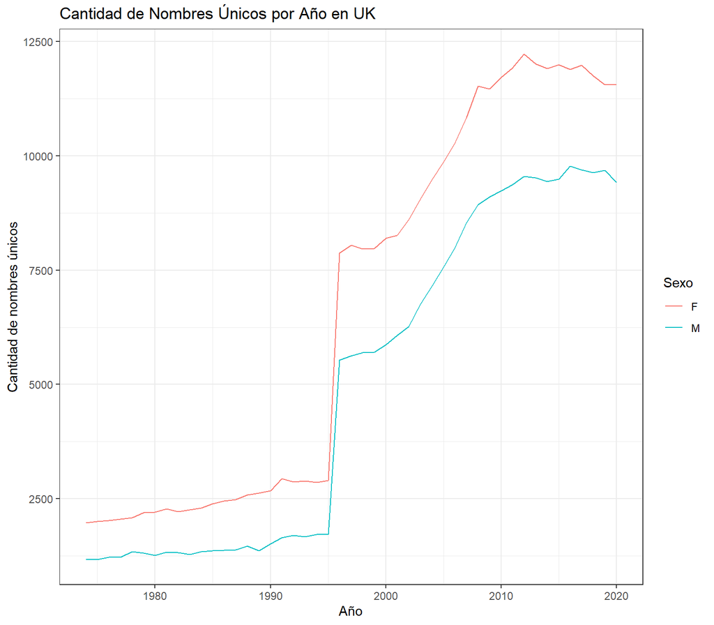

```r
unique_names <- data2 %>%
  group_by(year, sex) %>%
  summarize(unique_count = n_distinct(name)) %>%
  ungroup()

ggplot(unique_names, aes(x = year, y = unique_count, color = sex)) +
  geom_line() +
  labs(title = "Cantidad de Nombres Únicos por Año en UK",
       x = "Año", y = "Cantidad de nombres únicos", color = "Sexo") +
  theme(plot.title = element_text(face = "bold"))+
  theme_bw()
```

Al igual que en US, los nombres únicos siguieron una tendencia positiva. Se observa un salto repentino a partir del año 1995, debido a la incorporación de los datos de dos países más (Inglaterra y Gales e Irlanda del Norte) al conjunto de datos. Aun así, la cantidad de nombres únicos aumentó con el tiempo.

# 4 - Análisis de ambos países

> 1. **Nombres femeninos más populares**

Aquí echamos un vistazo a los principales nombres femeninos en la base de datos completa y observamos las tendencias de alguno de los nombres principales.

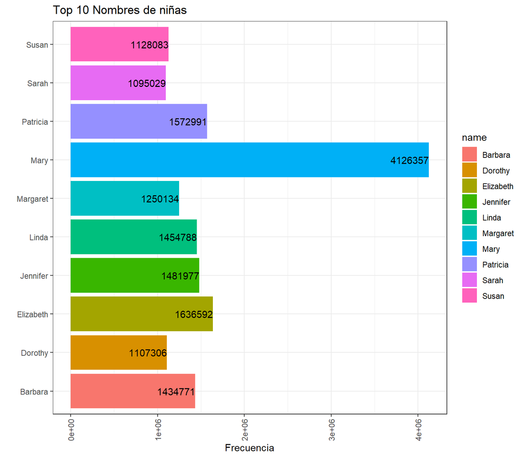

```r
data_females <- data3 %>%
  filter( sex == "F") %>%
  select(name, n,) %>%
  group_by(name) %>%
  summarise(total = sum(n)) %>%
  arrange(desc(total)) %>%
  head(10)

ggplot(data_females, aes(x = name, y = total, fill = name)) +
  geom_col() +
  labs(x = "", y = "Frecuencia", title = "Top 10 Nombres de niñas") +
  theme_bw() +
  geom_text(aes(label = total), vjust = 0.5,hjust = 1)+
  theme(axis.text.x = element_text(angle = 90, vjust = 0.5, hjust=1))+
  coord_flip()
```

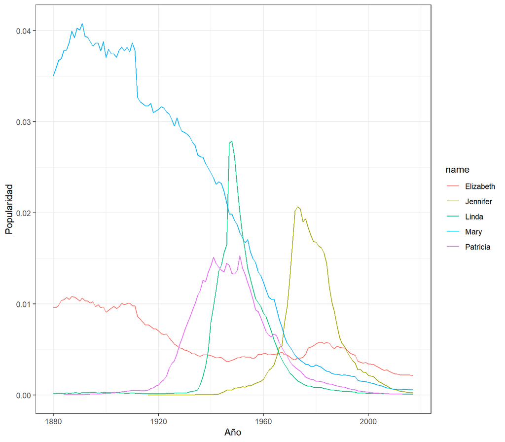

```r
data3 %>%
  filter(year >= 1880, year <= 2017, name %in% c('Mary','Elizabeth', 'Patricia', 'Jennifer', 'Linda'),sex=='F') %>%   group_by(name, year) %>%
  summarise(prop = sum(prop)) %>%
  ggplot(aes(year, prop, color = name)) +
  geom_line()+
    xlab("Año") +
  ylab("Popularidad") +
  theme_bw()
```

> 2. **Nombres masculinos más populares**

Principales nombres masculinos

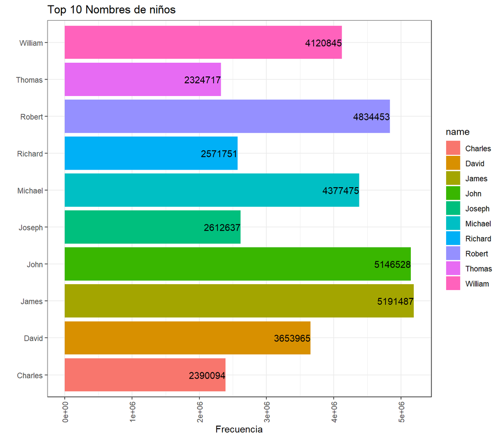

```r
data_males <- data3 %>%
  filter( sex == "M") %>%
  select(name, n) %>%
  group_by(name) %>%
  summarise(total = sum(n)) %>%
  arrange(desc(total)) %>%
  head(10)

ggplot(data_males, aes(x = name, y = total, fill = name)) +
  geom_col() +
  labs(x = "", y = "Frecuencia", title = "Top 10 Nombres de niños") +
  theme_bw() +
  geom_text(aes(label = total), vjust = 0.5,hjust = 1)+
  theme(axis.text.x = element_text(angle = 90, vjust = 0.5, hjust=1))+
  coord_flip()
```

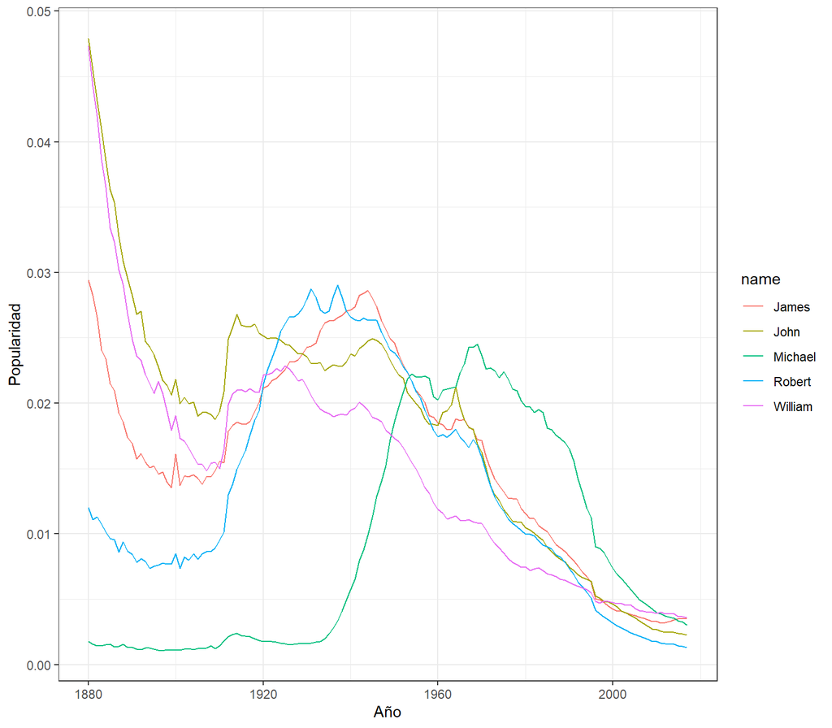

```r
data3 %>%
  filter(year >= 1880, year <= 2017, name %in% c('James', 'John', 'Robert', 'Michael', 'William'),sex=='M') %>%
  group_by(name, year) %>%
  summarise(prop = sum(prop)) %>%
  ggplot(aes(year, prop, color = name))+
  geom_line()+
    xlab("Año") +
  ylab("Popularidad") +
  theme_bw()
```

# 5 - Nombres unisex

Extraemos nombres unisex.

```r
females <- data3 %>% filter( sex == "F") %>% group_by(name) %>%  summarise(Total = sum(n)) %>% arrange(desc(Total))

males <- data3 %>% filter( sex == "M") %>% group_by(name) %>%  summarise(Total = sum(n)) %>% arrange(desc(Total))

unisex_names = intersect(females$name,males$name)
unisex_names_df <- data3 %>% filter(name %in% unisex_names)
```

> 1. **Nombres unisex**

Vemos los nombres unisex más populares.

```r
unisex_m_f = data3%>% filter(name %in% unisex_names) %>% group_by(name,sex) %>% summarise(total = sum(n))%>% arrange(desc(total))
paged_table(head(unisex_m_f))
```

| name | sex | total |
| --- | --- | --- |
| James | M | 5191487 |
| John | M | 5146528 |
| Robert | M | 4834453 |
| Michael | M | 4377475 |
| Mary | F | 4126357 |
| William | M | 4120845 |

¿Los nombres James para una niña y Mary para un niño?

¿En serio?

¡Vamos a comprobarlo!

```r
data3 %>% select(name,sex,n) %>%  filter(name %in% c("James","Mary")) %>% group_by(name,sex) %>% summarise(total = sum(n))
```

```
## # A tidytable: 4 × 3
## # Groups:      name
##   name  sex     total
##   <chr> <chr>   <dbl>
## 1 James F       23368
## 2 James M     5191487
## 3 Mary  F     4126357
## 4 Mary  M       15164
```

Por extraño que me parezca hay chicas que se llaman James y chicos que se llaman Mary. Como se suele decir “Code never lies”.

> 2. **Nombres unisex más populares**

Veamos la tendencia de estos nombres unisex populares a lo largo de los años

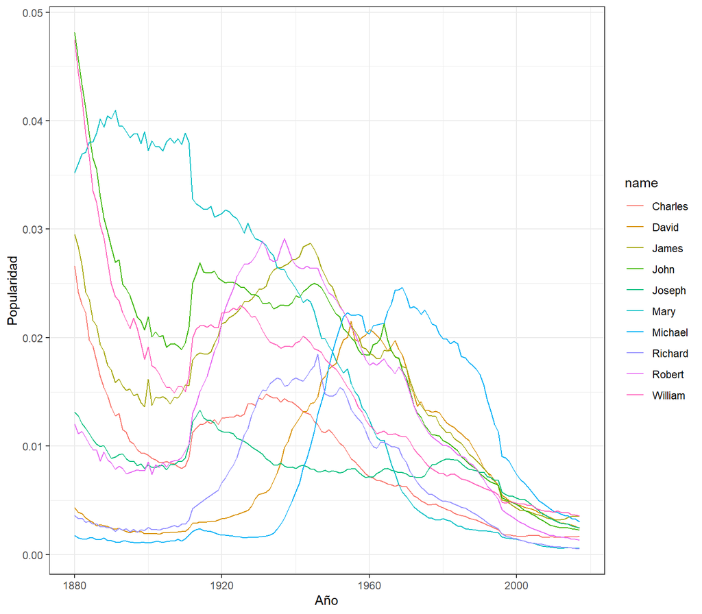

```r
data3 %>%
  filter(year >= 1880, year <= 2017, name %in% c('James', 'John', 'Robert', 'Michael', 'Mary', 'William', 'David', 'Joseph', 'Richard', 'Charles')) %>%
  group_by(name, year) %>%
  summarise(prop = sum(prop)) %>%
  ggplot(aes(year, prop, color = name)) +
  geom_line()+
    xlab("Año") +
  ylab("Popularidad") +
  theme_bw()
```

Al principio John, William y Mary eran los nombres unisex más famosos. Su popularidad disminuyó hacia 1900, pero Mary seguía siendo una opción popular. Todos los nombres empezaron con una tendencia negativa, pero volvieron a ser populares después de 1910 y se hicieron más populares en la década de 1940. Después, sólo Michael y David mostraron una tendencia positiva. Con el tiempo, todos los nombres adoptaron una tendencia negativa a medida que aparecían más nombres únicos.

Hasta ahora hemos visto nombres unisex a lo largo de todos los años. Veamos algunos nombres de ciertos años específicos…

> 3. **Los nombres unisex más populares en 1974**

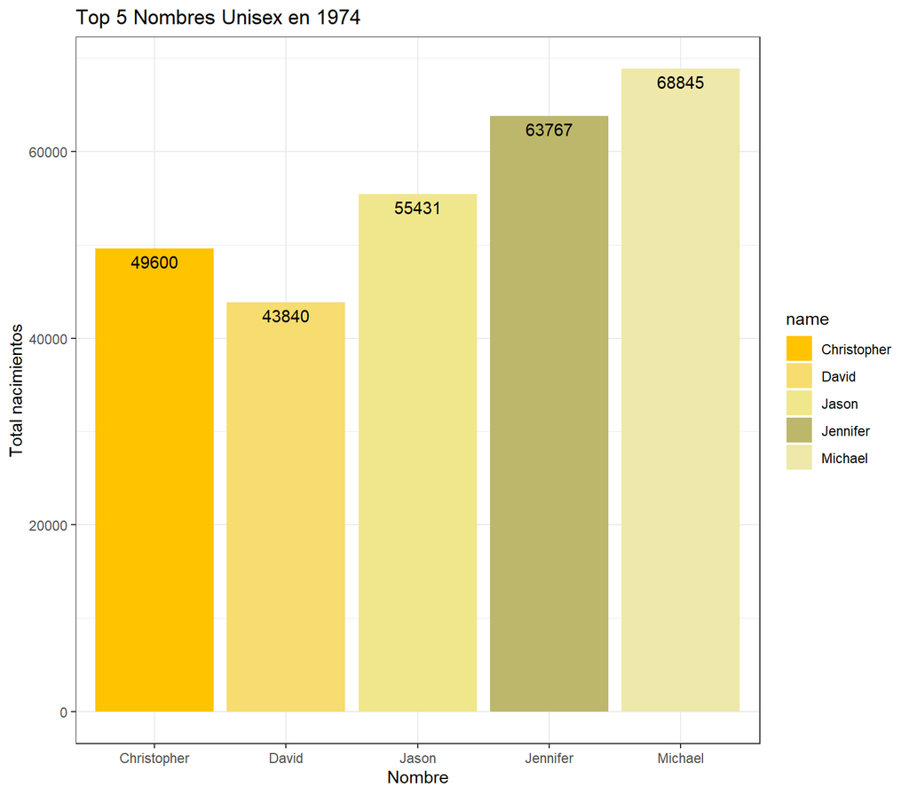

```r
unisex_1974 <- data3 %>%
  filter(year == 1974, name %in% unisex_names) %>%
  group_by(name) %>%
  summarise(total = sum(n)) %>%
  arrange(desc(total)) %>%
  head(5)

ggplot(unisex_1974, aes(x = name, y = total, fill = name)) +
  geom_bar(stat = "identity") +
  geom_text(aes(label = total), vjust = 1.5,hjust = 0.5)+
  scale_fill_manual(values = c("#FFC300", "#F7DC6F", "#F0E68C", "#BDB76B", "#EEE8AA")) +
  labs(x = "Nombre", y = "Total nacimientos", title = "Top 5 Nombres Unisex en 1974") +
  theme_bw()
```

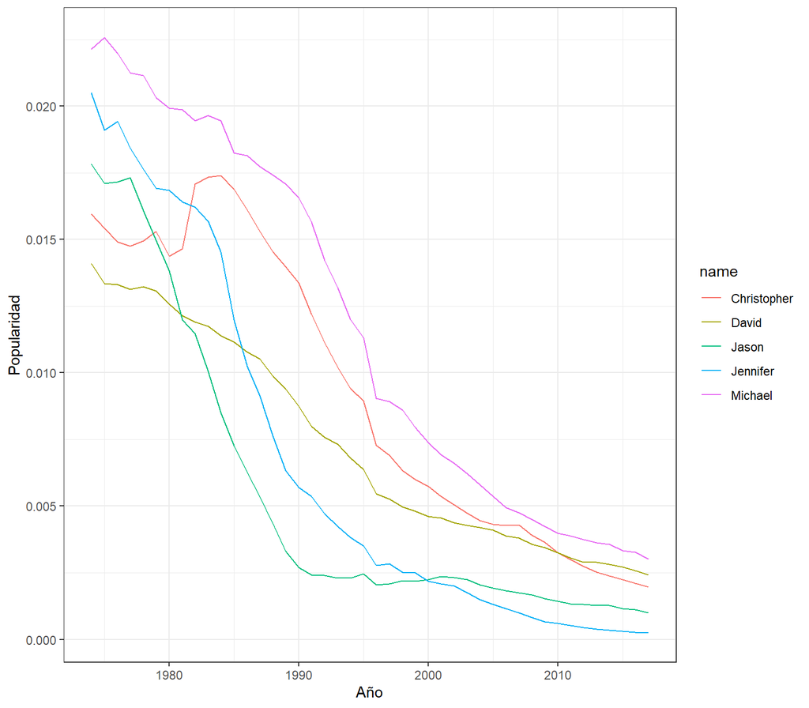

```r
data3 %>%
  filter(year >= 1974, year <= 2017, name %in% c('Christopher', 'David', 'Jason', 'Jennifer', 'Michael')) %>%
  group_by(name, year) %>%
  summarise(prop = sum(prop)) %>%
  ggplot(aes(year, prop, color = name)) +
  geom_line()+
    xlab("Año") +
  ylab("Popularidad") +
  theme_bw()
```

Observamos que todos los nombres perdieron popularidad en los años siguientes, aunque Jennifer y Jason lo hicieron antes que los demás.

> 4. **Los nombres unisex más populares en 2017**

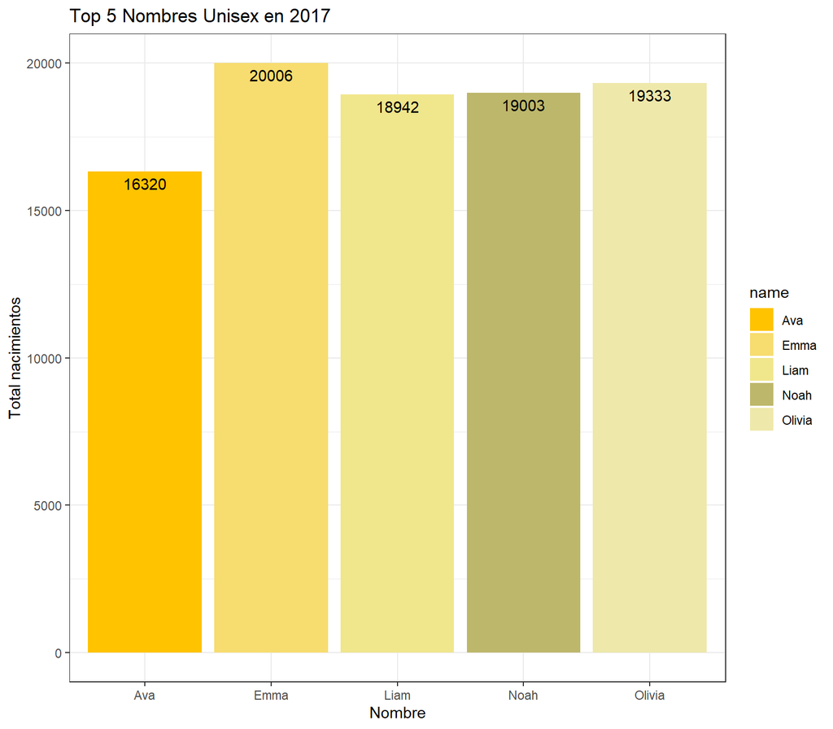

```r
unisex_2017 <- data3 %>%
  filter(year == 2017, name %in% unisex_names) %>%
  group_by(name) %>%
  summarise(total = sum(n)) %>%
  arrange(desc(total)) %>%
  head(5)

ggplot(unisex_2017, aes(x = name, y = total, fill = name)) +
  geom_bar(stat = "identity") +
  scale_fill_manual(values = c("#FFC300", "#F7DC6F", "#F0E68C", "#BDB76B", "#EEE8AA")) +
  labs(x = "Nombre", y = "Total nacimientos", title = "Top 5 Nombres Unisex en 2017") +
  geom_text(aes(label = total),  vjust = 1.5,hjust = 0.5)+
  theme_bw()
```

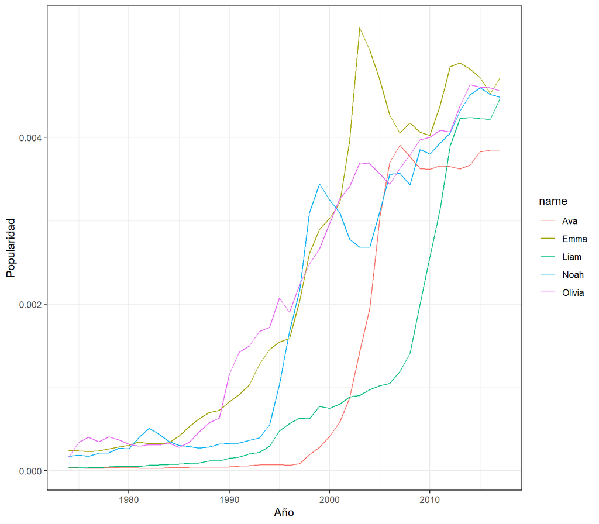

```r
data3 %>%
  filter(year >= 1974, year <= 2017, name %in% c('Ava', 'Emma', 'Liam', 'Noah', 'Olivia')) %>%
  group_by(name, year) %>%
  summarise(prop = sum(prop)) %>%
  ggplot(aes(year, prop, color = name)) +
  geom_line()+
    xlab("Año") +
  ylab("Popularidad") +
  theme_bw()
```

Todos estos nombres eran menos populares antes de 1990, pero empezaron a hacerse populares a partir de 1990. Emma fue muy popular durante 2002-2003. Incluso después de una ligera caída, ocupó el primer puesto en 2017.

> 5. **Curioso caso de James y Mary**

Como el último análisis de los nombres unisex, trataré de ver las tendencias de cómo los nombres “James” en femenino y “Mary” en masculino fueron los preferidos a lo largo de los años.

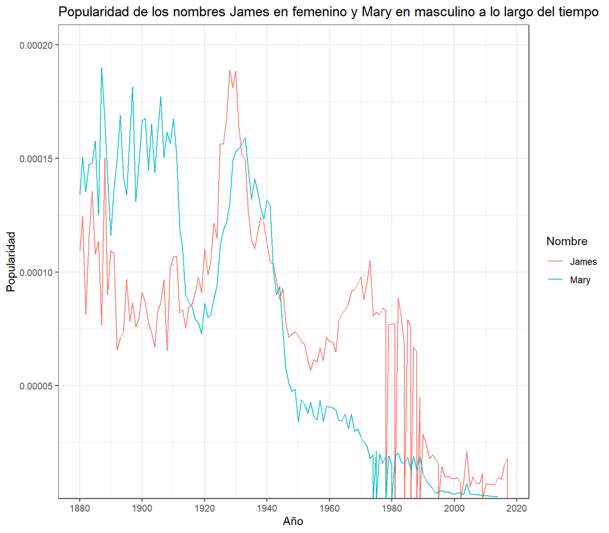

```r
james = data3 %>% select(name,year,sex,prop) %>% filter(name=="James",sex=="F") %>% group_by(name,year)
mary = data3 %>% select(name,year,sex,prop) %>% filter(name=="Mary",sex=="M") %>% group_by(name,year)

names_data <- rbind(james, mary)

ggplot(names_data, aes(x = year, y = prop, color = name)) +
  geom_line(size = 0.5) +
  scale_x_continuous(breaks = seq(1880, 2020, 20)) +
  scale_y_continuous(expand = expansion(mult = c(0, 0.1))) +
  labs(title = "Popularidad de los nombres James en femenino y Mary en masculino a lo largo del tiempo",
       x = "Año",
       y = "Popularidad",
       color = "Nombre")+
  theme_bw()
```

Podemos ver que durante los primeros años el nombre Mary era más famoso para los chicos que James para las chicas. Con el tiempo, Mary fue menos preferido, pero las personas siguieron nombrando a algunas niñas como James.

# 6 - Análisis por Ranking

> 1. **Nombres en el puesto Nº 1**

Los nombres que ocuparon la primera posición la mayoría de los años.

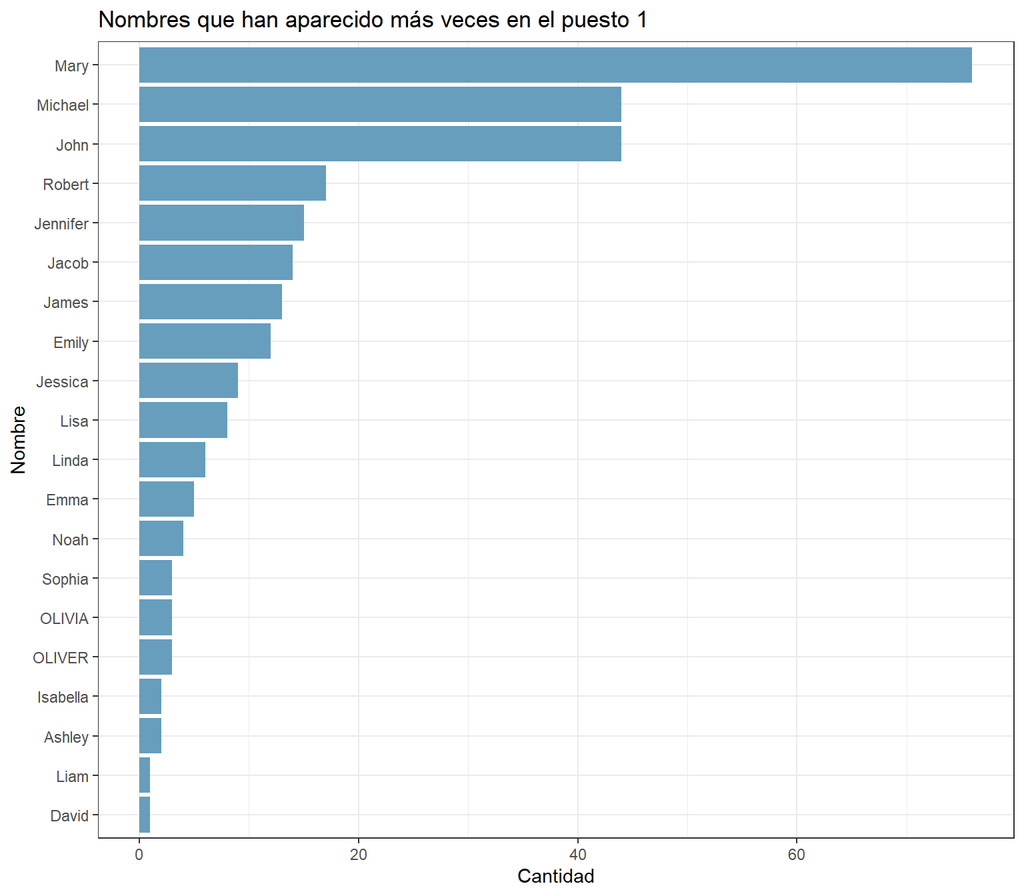

```r
rank_1 <- data3 %>%
  select(name, rank) %>%
  group_by(name) %>%
  filter(rank == 1) %>%
  summarise(count = n()) %>%
  arrange(desc(count), name)

ggplot(rank_1, aes(count, reorder(name, count))) +
  geom_bar(stat = "identity") +
   geom_col(fill = "#6baed6", alpha = 0.8) +
  labs(title = "Nombres que han aparecido más veces en el puesto 1", x = "Cantidad", y = "Nombre") +
  theme_bw()
```

El gráfico es bastante claro. Mary se mantuvo en el puesto número 1 la mayoría de las veces en comparación con cualquier otro nombre, y le siguieron Michael y John, que ocuparon el primer puesto el mismo número de veces.

> 2. **Toppers**

Los nombres que han permanecido entre los cinco primeros durante más años.

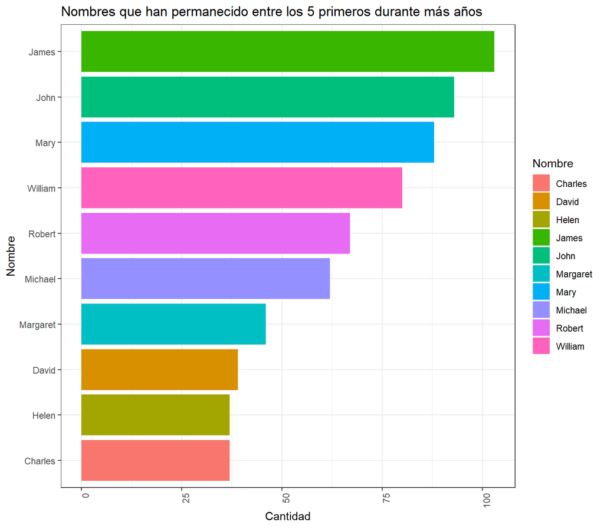

```r
top_names <- data3 %>%
  select(year, name, rank) %>%
  filter(rank <= 5) %>%
  group_by(name) %>%
  summarise(years = n()) %>%
  arrange(-years) %>%
  top_n(10)

ggplot(top_names, aes(x = reorder(name, years), y = years, fill = name)) +
  geom_bar(stat = "identity") +
  labs(title = "Nombres que han permanecido entre los 5 primeros durante más años", x = "Nombre", y = "Cantidad") +
  theme_bw() +
  theme(axis.text.x = element_text(angle = 90, hjust = 1)) +
  scale_fill_discrete(name = "Nombre")+
  coord_flip()
```

Así, James, seguido de John y Mary, han estado en la lista de los 5 nombres más populares durante más años. Se puede decir que estos nombres son los más populares en sentido estricto.

# 7 - Natalidad y proporción de sexos

> 1. **Análisis del conjunto**
- **Tasa de natalidad total**

  Nacimiento total por sexo y año

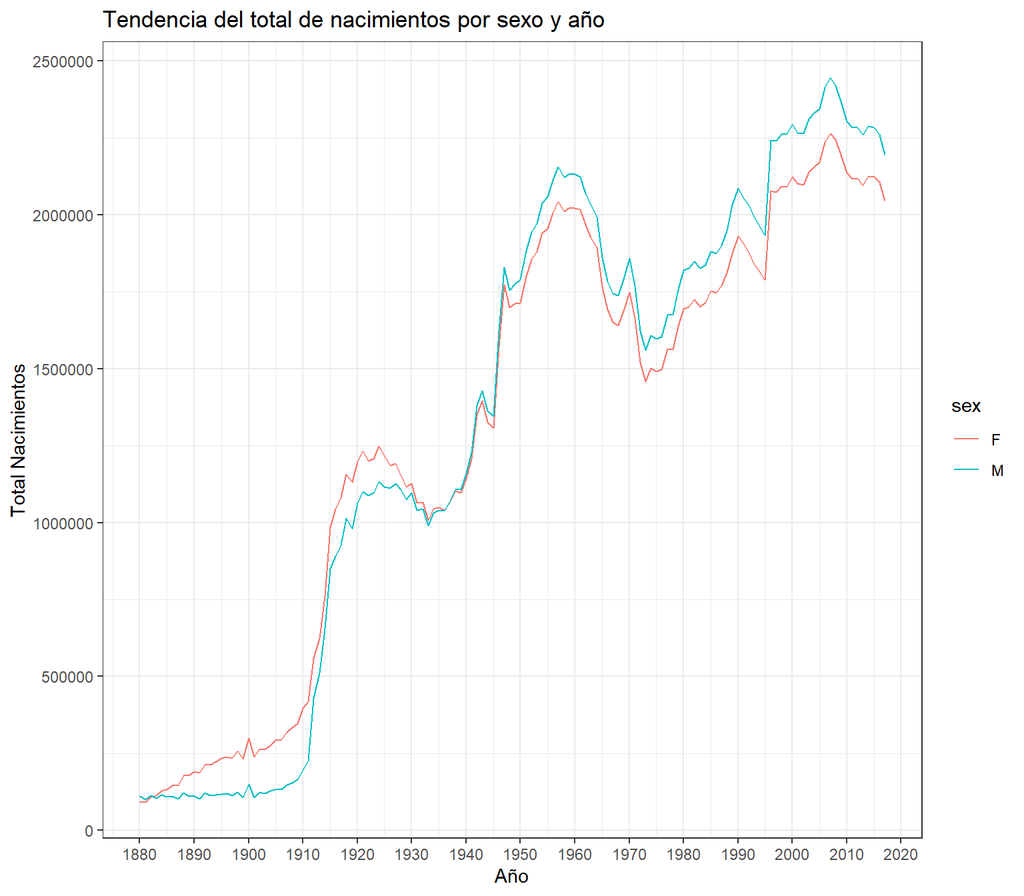

```r
total_births <- data3 %>%filter(year<=2017) %>%
  group_by(sex, year) %>%
  summarise(total_births = sum(n))

ggplot(total_births, aes(x = year, y = total_births, group = sex, color = sex)) +
  geom_line(size = 0.5) +
  scale_x_continuous(breaks = seq(1880, 2020, 10)) + # Add x-axis breaks for every 10 years
  labs(title = "Tendencia del total de nacimientos por sexo y año", x = "Año", y = "Total Nacimientos") +
  theme_bw()+facet_grid()
```

En el gráfico anterior observamos cómo varía el número de hombres y mujeres a lo largo de los años. Nacieron más mujeres hasta 1935, el patrón cambió después de 1945, entonces nacieron más hombres y esa tendencia continuó hasta 2017.

- **Proporción de sexos**

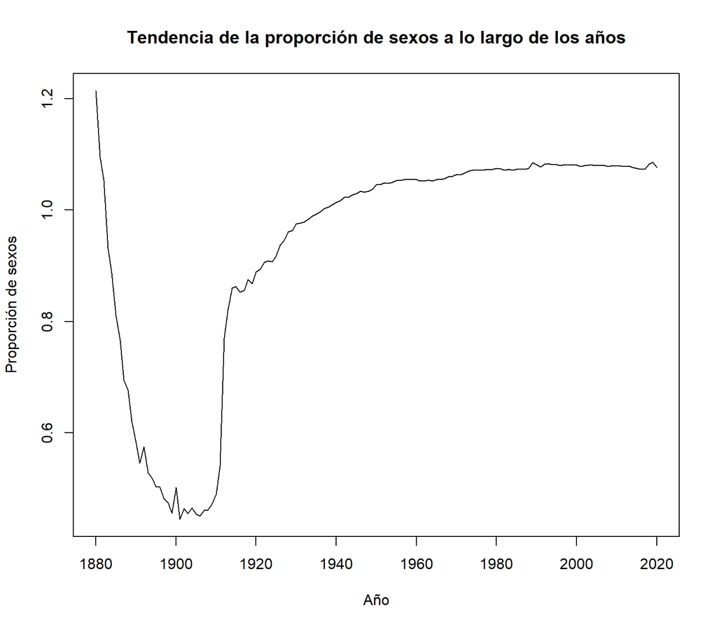

```r
total_male_births <- aggregate(n ~ year + sex, data = data3[data3$sex == "M", ], sum)
total_female_births <- aggregate(n ~ year + sex, data = data3[data3$sex == "F", ], sum)

merged_df <- merge(total_male_births, total_female_births, by = "year")
merged_df$sex_ratio <- merged_df$n.x / merged_df$n.y

plot(merged_df$year, merged_df$sex_ratio, type = "l", xlab = "Año", ylab = "Proporción de sexos", main = "Tendencia de la proporción de sexos a lo largo de los años")
```

Aquí hay datos interesantes, a principios de 1880 la proporción de sexos es superior a 1, lo que significa que nacieron más niños que niñas. Sin embargo, en torno a 1900, la situación es totalmente opuesta: nacen muchas más niñas que niños. Por último, a partir de 1940, la proporción de sexos se sitúa casi en torno a 1, lo que indica un buen equilibrio en el número de hombres y mujeres.

> 2. **Comparación entre países**
- **Comparamos la natalidad de dos países.**

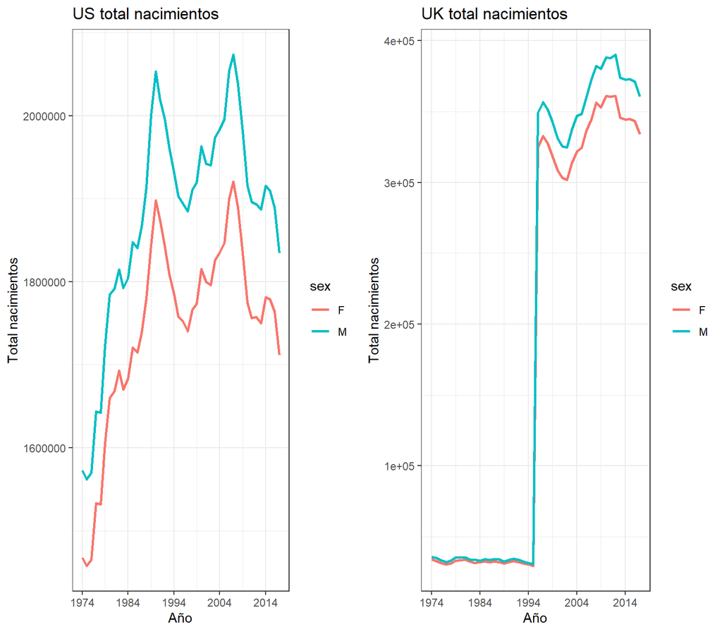

```r
us_births <- data1 %>% filter(year >= 1974, year <= 2017)
uk_births <- data2 %>% filter(year >= 1974, year <= 2017)

us_total_births <- us_births %>%
  group_by(sex, year) %>%
  summarise(total_births = sum(n))
uk_total_births <- uk_births %>%
  group_by(sex, year) %>%
  summarise(total_births = sum(n))

us_plot = ggplot(us_total_births, aes(x = year, y = total_births, group = sex, color = sex)) +
  geom_line(size = 1) +
  scale_x_continuous(breaks = seq(1974, 2017, 10)) +
  labs(title = "US total nacimientos", x = "Año", y = "Total nacimientos") +
  theme_bw()

uk_plot = ggplot(uk_total_births, aes(x = year, y = total_births, group = sex, color = sex)) +
  geom_line(size = 1) +
  scale_x_continuous(breaks = seq(1974, 2017, 10)) +
  labs(title = "UK total nacimientos", x = "Año", y = "Total nacimientos") +
  theme_bw()
grid.arrange(us_plot, uk_plot, ncol = 2)
```

En US la tendencia se mantuvo prácticamente igual, nacieron más niños que niñas. En UK, las tasas de natalidad de niños y niñas eran prácticamente iguales, pero cambiaron a partir de 1995, cuando nacieron más niños que niñas.El pronunciado aumento en UK se debe a la incorporación de dos bases de datos más a la base de datos original de Escocia.

- **Comparación de la proporción de sexos**

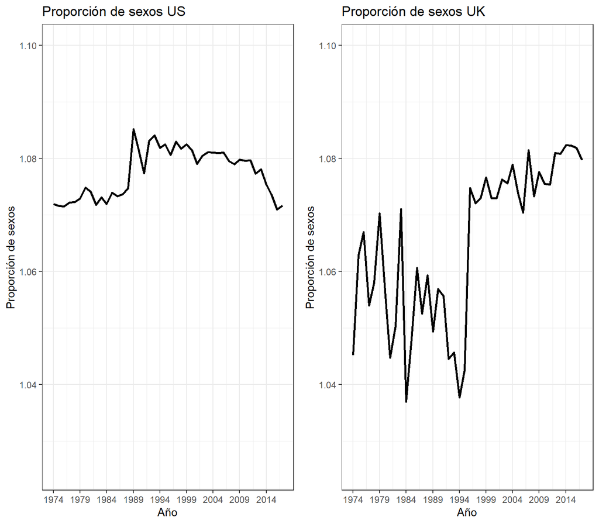

```r
us_total_male_births <- data1 %>% filter(sex == "M",year >= 1974, year <= 2017) %>%
  group_by(year) %>%
  summarise(total_male_births = sum(n))
us_total_female_births <- data1 %>% filter(sex == "F",year >= 1974, year <= 2017) %>%
  group_by(year) %>%
  summarise(total_female_births = sum(n))

uk_total_male_births <- data2 %>% filter(sex == "M",year >= 1974, year <= 2017) %>%
  group_by(year) %>%
  summarise(total_male_births = sum(n))
uk_total_female_births <- data2 %>% filter(sex == "F",year >= 1974, year <= 2017) %>%
  group_by(year) %>%
  summarise(total_female_births = sum(n))

us_sex_ratio <- us_total_male_births$total_male_births / us_total_female_births$total_female_births
uk_sex_ratio <- uk_total_male_births$total_male_births / uk_total_female_births$total_female_births


us_plot <- ggplot(data.frame(year = us_total_male_births$year, sex_ratio = us_sex_ratio),
                  aes(x = year, y = sex_ratio)) +
  geom_line(size = 1) +
  scale_x_continuous(breaks = seq(1974, 2017, 5)) +
  labs(title = "Proporción de sexos US", x = "Año", y = "Proporción de sexos") +
  scale_y_continuous(limits = c(1.025, 1.1)) +
  theme_bw()

uk_plot <- ggplot(data.frame(year = uk_total_male_births$year, sex_ratio = uk_sex_ratio),
                  aes(x = year, y = sex_ratio)) +
  geom_line(size = 1) +
  scale_x_continuous(breaks = seq(1974, 2017, 5)) +
  labs(title = "Proporción de sexos UK", x = "Año", y = "Proporción de sexos") +
  scale_y_continuous(limits = c(1.025, 1.1)) +
  theme_bw()

grid.arrange(us_plot, uk_plot, ncol = 2)
```

La proporción de sexos de US parece casi la misma en todo momento, sin embargo, en el caso del UK es más fluctuante. Podemos ver un claro repunte en la proporción de sexos durante el año 1995-96, esto se debe a los nuevos datos que se introdujeron en la base de datos a partir de este año.

# 8 - Análisis Curioso

Me pregunto qué nombres se daban cuando yo nací y si mi nombre aparecía en la base de datos de alguno de esos años.

> 1. **Mi año de nacimiento - 1992**

Tomando el año 1992 y poniendo los 100 primeros babynames masculinos en wordcloud.

```r
data3 %>%
  filter(year == 1992) %>%
  filter(sex == "M") %>%
  select(name, n) %>%
  top_n(100, n) %>%
  wordcloud2(size = .5)
```

[interactive chart not shown]

> 2. **Shrikant**

Ahora voy a buscar mi nombre en el conjunto de datos completo.Ya que soy de la India, las posibilidades de que mi nombre aparezca son bajas.

```r
data3 %>% filter(name =="Shrikant") %>%head(6)
```

```
## # A tidytable: 0 × 7
## # Groups:      year, sex
## # … with 7 variables: year <dbl>, sex <chr>, name <chr>, n <dbl>, prop <dbl>,
## #   country <chr>, rank <dbl>
```

Como podemos ver, mi nombre no aparece en la lista. Hay otra forma de escribir mi nombre que es popular en el sur de mi país. Intentémoslo con ello.

```r
data3 %>% filter(name =="Srikanth") %>% paged_table()
```

| year | sex | name | n | prop | country | rank |
| --- | --- | --- | --- | --- | --- | --- |
| 1978 | M | Srikanth | 5 | 1.543915e-06 | US | 702 |
| 1989 | M | Srikanth | 8 | 2.047587e-06 | US | 764 |

Ahí está, mis tocayos nacieron en los años 1978 y 1989, todos ellos en US.

> 3. **Carlos**

Aunque mi nombre exacto no aparecía en la base de datos, conozco un nombre que debería estar en ella, “Carlos”.

```r
data3 %>% select(year,sex,name,n,country) %>%  filter(name =="Carlos") %>% paged_table()
```

| year | sex | name | n | country |
| --- | --- | --- | --- | --- |
| 1880 | M | Carlos | 17 | US |
| 1881 | M | Carlos | 19 | US |
| 1882 | M | Carlos | 20 | US |
| 1883 | M | Carlos | 22 | US |
| 1884 | M | Carlos | 13 | US |
| 1885 | M | Carlos | 28 | US |
| 1886 | M | Carlos | 16 | US |
| 1887 | M | Carlos | 20 | US |
| 1888 | M | Carlos | 29 | US |
| 1889 | M | Carlos | 25 | US |

[output cut: 257 more lines]

Parece un nombre popular, veamos su popularidad a lo largo de los años.

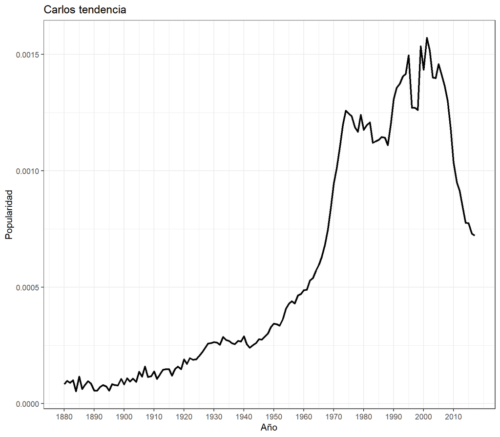

```r
carlos = data3 %>% select(year,name,prop) %>% filter(year <= 2017,name=="Carlos") %>% group_by(year) %>% summarise(prop = sum(prop))
  ggplot(carlos,aes(x = year, y = prop)) +
  geom_line(size = 1) +
  scale_x_continuous(breaks = seq(1880, 2017, 10)) +
  labs(title = "Carlos tendencia", x = "Año", y = "Popularidad") +
  theme_bw()
```

Parece que después de 1945 “Carlos” se hizo popular, alcanzando su punto máximo de popularidad alrededor del año 2000. Carlos también apareció en 1992, a ver si lo encuentras en el wordcloud arriba.

> 4. **Nombres por letra inicial**

Cuando pienso en los nombres me surge otra pregunta interesante: al decidir un nombre para un bebé, ¿qué debemos elegir como primera letra? ¿La letra común o la rara?

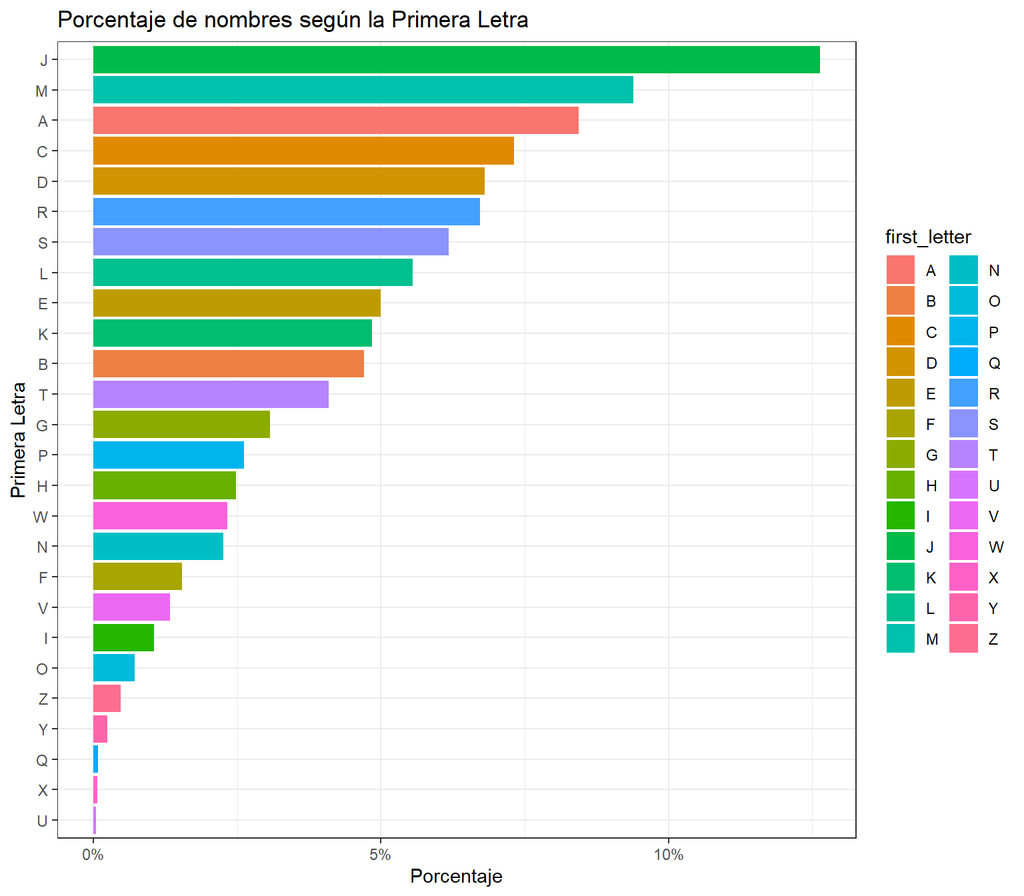

```r
names_by_letter <- data3 %>% select(name, n) %>% group_by(name) %>%
  summarise(total_n = sum(n)) %>%
  mutate(first_letter = substr(name, 1, 1)) %>%
   filter(!(first_letter %in% c("o", "e", "a", "-")))

names_by_letter <- names_by_letter %>%
  mutate(percentage = total_n / sum(total_n))

names_by_letter = names_by_letter %>% group_by(first_letter) %>% summarise(percentage = sum(percentage))

ggplot(names_by_letter, aes(x = reorder(first_letter,percentage), y = percentage, fill = first_letter)) +
  geom_bar(stat = "identity") +
    labs(title = "Porcentaje de nombres según la Primera Letra", x = "Primera Letra", y = "Porcentaje") +
  scale_y_continuous(labels = scales::percent_format()) +
  theme_bw()+
coord_flip()
```

Los nombres que empiezan por J, M y A son los más populares y comunes. Si se quiere ser creativo, se puede usar la letra X, como Elon Musk que llamó a su hijo (X Æ A-12).

[figure not shown]